# Project: Investigate the dataset "Medical Appointment No Shows"

- Introduction
- Questions
- Required packages, magic functions, and personalized functions
- Data Wrangling
- Exploratory Data Analysis
- Main Data Analysis
- Conclusions

## Introduction

This project analyzes the dataset named "Medical Appointment No Shows". This dataset collects information from over 100k medical appointments in Brazil and is focused on the question of whether or not patients show up to their appointments. A number of characteristics about the patient are included in each row. The source of this data can be found at: [Kaggle](https://www.kaggle.com/joniarroba/noshowappointments).

One person schedules an appointment, but still does not show up. Can we understand why this happens? Here, I will investigate a series of questions on this dataset (see below) with a variety of descriptive statistics and graphical representations. For this, first I will load, inspect and modify the dataset in order to clean it and prepare it for further analysis. Then, I will briefly describe the nature of the variables. Further, I will calculate various descriptive measures and graphical representations to look at the differences between groups of interest. Each question will be handled separately. I will end my analysis with a final section summing up my conclusions of this analysis.

## Questions

1. Do no-shows occur more often in specific days or months?
2. Do no-shows occur more often among men or women?
3. Are no-shows related with a person's health status?
4. Is social support influencing the rate of appointment no-shows?
5. Is distance from appointment locations related to no-shows?
6. Does the SMS message number influence the rate of no-shows?

## Required packages, magic functions, and personalized functions

```python
# Required packages:
import numpy as np
import pandas as pd
import datetime as dt
import matplotlib.pyplot as plt
import seaborn as sns

# Magic functions:
%matplotlib inline

# Personalized functions:
def rate_to_percent(x):
    return "{} %".format(round(x*100,2))
```

## Data Wrangling

### General properties:

```python
# Load data:
data = pd.read_csv("noshow_data.csv")

# First glance at the dataset:
print("Data dimensions (row nr., column nr.) are: ", data.shape)
data.head()
```

```
Data dimensions (row nr., column nr.) are:  (110527, 14)
```

|  | PatientId | AppointmentID | Gender | ScheduledDay | AppointmentDay | Age | Neighbourhood | Scholarship | Hipertension | Diabetes | Alcoholism | Handcap | SMS_received | No-show |
| --- | --- | --- | --- | --- | --- | --- | --- | --- | --- | --- | --- | --- | --- | --- |
| 0 | 2.987250e+13 | 5642903 | F | 2016-04-29T18:38:08Z | 2016-04-29T00:00:00Z | 62 | JARDIM DA PENHA | 0 | 1 | 0 | 0 | 0 | 0 | No |
| 1 | 5.589978e+14 | 5642503 | M | 2016-04-29T16:08:27Z | 2016-04-29T00:00:00Z | 56 | JARDIM DA PENHA | 0 | 0 | 0 | 0 | 0 | 0 | No |
| 2 | 4.262962e+12 | 5642549 | F | 2016-04-29T16:19:04Z | 2016-04-29T00:00:00Z | 62 | MATA DA PRAIA | 0 | 0 | 0 | 0 | 0 | 0 | No |
| 3 | 8.679512e+11 | 5642828 | F | 2016-04-29T17:29:31Z | 2016-04-29T00:00:00Z | 8 | PONTAL DE CAMBURI | 0 | 0 | 0 | 0 | 0 | 0 | No |
| 4 | 8.841186e+12 | 5642494 | F | 2016-04-29T16:07:23Z | 2016-04-29T00:00:00Z | 56 | JARDIM DA PENHA | 0 | 1 | 1 | 0 | 0 | 0 | No |

```python
# Descriptive statistics for numerical variables in dataset:
round(data.describe(), 1)
```

|  | PatientId | AppointmentID | Age | Scholarship | Hipertension | Diabetes | Alcoholism | Handcap | SMS_received |
| --- | --- | --- | --- | --- | --- | --- | --- | --- | --- |
| count | 1.105270e+05 | 110527.0 | 110527.0 | 110527.0 | 110527.0 | 110527.0 | 110527.0 | 110527.0 | 110527.0 |
| mean | 1.474963e+14 | 5675305.1 | 37.1 | 0.1 | 0.2 | 0.1 | 0.0 | 0.0 | 0.3 |
| std | 2.560949e+14 | 71295.8 | 23.1 | 0.3 | 0.4 | 0.3 | 0.2 | 0.2 | 0.5 |
| min | 3.921780e+04 | 5030230.0 | -1.0 | 0.0 | 0.0 | 0.0 | 0.0 | 0.0 | 0.0 |
| 25% | 4.172614e+12 | 5640285.5 | 18.0 | 0.0 | 0.0 | 0.0 | 0.0 | 0.0 | 0.0 |
| 50% | 3.173184e+13 | 5680573.0 | 37.0 | 0.0 | 0.0 | 0.0 | 0.0 | 0.0 | 0.0 |
| 75% | 9.439172e+13 | 5725523.5 | 55.0 | 0.0 | 0.0 | 0.0 | 0.0 | 0.0 | 1.0 |
| max | 9.999816e+14 | 5790484.0 | 115.0 | 1.0 | 1.0 | 1.0 | 1.0 | 4.0 | 1.0 |

```python
# Look at the nature of variables and check for missing values:
data.info()
```

```
<class 'pandas.core.frame.DataFrame'>
RangeIndex: 110527 entries, 0 to 110526
Data columns (total 14 columns):
PatientId         110527 non-null float64
AppointmentID     110527 non-null int64
Gender            110527 non-null object
ScheduledDay      110527 non-null object
AppointmentDay    110527 non-null object
Age               110527 non-null int64
Neighbourhood     110527 non-null object
Scholarship       110527 non-null int64
Hipertension      110527 non-null int64
Diabetes          110527 non-null int64
Alcoholism        110527 non-null int64
Handcap           110527 non-null int64
SMS_received      110527 non-null int64
No-show           110527 non-null object
dtypes: float64(1), int64(8), object(5)
memory usage: 11.8+ MB
```

### Short description:

The dataset is composed of 14 variables (columns) and 110527 observations (rows), with no missing values. Variables may be of different types and nature. Unique identification numbers (IDs) are numerical variables, personal information (age, gender, address and health condition) are numerical or categorical, as well as appointment information (schedule time and SMS reminders). The dependent variable of interest is 'No-show' which means whether the patient did or did not go to the appointment.

- "PatientId" and "AppointmentID" are set as numerical (i.e., float and int), but probably they should be analyzed as categorical variables (strings).
- Variables related to date ("ScheduleDay" and "AppointmentDay") are set as strings, but they should be set to datetime, in order for analysis to account for the specific time-points, not only weekdays, but maybe also months and years.
- "Scholarship" is of integer type ("0/1", which actually represents "no/yes"). The same is true for "Hipertension", "Diabetes", "Alcoholism", "Handcap" and "SMS_received".
- For age, we may notice a negative value in its range. Since age cannot be negative, this must be corrected.

### What needs to be done:

Not all variables, however, would be interesting to use in the analysis. For example "AppointmentID" might not be informative to relate to "No-show", or the time an appointment was set, i.e., "ScheduleDay". These variables could be removed from the dataset, to spare some computing time and memory usage during the analysis. In addition, variable names could be edited, for better comprehension and ease of coding. Moreover, "No-show" may be a tricky variable, and perhaps the opposite may be more easy for understanding the analysis. That is, whether persons did indeed go to the appointments ("attendance"). Finally, there might be duplicated rows in the data, thus it needs to be further checked. In summary, we need to:

- Check for duplicates or NAs and remove them
- Remove unimportant variables
- Rename variable names
- Modify variable class types
- Create new values for dates and for successful appointments
- Check age values that are negative

#### Check for duplicates and remove them

```python
# Check whether duplicated rows exist:
print("Number of duplicated rows:", sum(data.duplicated()))
```

```
Number of duplicated rows: 0
```

```python
# Remove NAs:
data.dropna(inplace=True)
```

```python
# Is there more than one observation per patient?
print("Number of unique patients:", data['PatientId'].nunique())
```

```
Number of unique patients: 62299
```

> **Note:** The number of patient IDs is about 62k. However, the number of obserations is about 110k for the whole dataset (see the dataset size at the beginning of this section). Therefore, this means that patients had more than one appointment scheduled at some point with the doctors.

#### Remove unimportant variables (not considered in the analysis)

```python
# Drop 'AppointmentID' and 'ScheduledDay'
data.drop(columns=['AppointmentID', 'ScheduledDay'], inplace=True)
```

#### Rename variable names

```python
# Original column names:
print("Original column names are:")
data.columns
```

```
Original column names are:
```

```
Index(['PatientId', 'Gender', 'AppointmentDay', 'Age', 'Neighbourhood',
       'Scholarship', 'Hipertension', 'Diabetes', 'Alcoholism', 'Handcap',
       'SMS_received', 'No-show'],
      dtype='object')
```

```python
# Place underscores in the specific variables which were named with multiple words:
data.rename(columns={'PatientId': 'patient_id', 'AppointmentDay': 'appointment_day' }, inplace=True)
```

```python
# Replace any possible space or hifen with underscores, and set all variable names to lowercase (format names):
data.rename(columns=lambda x: x.strip().lower().replace(" ", "_"), inplace=True)
data.rename(columns=lambda x: x.strip().lower().replace("-", "_"), inplace=True)
```

```python
# Confirm new column names:
print("New column names are:")
data.columns
```

```
New column names are:
```

```
Index(['patient_id', 'gender', 'appointment_day', 'age', 'neighbourhood',
       'scholarship', 'hipertension', 'diabetes', 'alcoholism', 'handcap',
       'sms_received', 'no_show'],
      dtype='object')
```

#### Modify variable class types

```python
# Set IDs as categorical variables:
data['patient_id'] = data['patient_id'].astype(str)
```

```python
# Set "0/1" variables to categorical "No/Yes":
data[['scholarship','hipertension','diabetes','alcoholism','handcap']] = np.where(data[['scholarship','hipertension','diabetes','alcoholism','handcap']]==0, 'No', 'Yes')
```

```python
# Set time variable to datetime:
data['appointment_day'] = data['appointment_day'].astype('datetime64[ns]')
```

#### Create new values for dates and for successful appointments

```python
# Split appointment date into years, months and days of the week:
data['appointment_day_year'] = data['appointment_day'].dt.year
data['appointment_day_month'] = data['appointment_day'].dt.month
data['appointment_day_day'] = data['appointment_day'].dt.weekday
```

```python
# Create a new variable, the opposite to "no_show":
data['attendance'] = np.where(data['no_show']=='Yes', "No", "Yes")
# Create it again, but as a numerical variable to allow for plotting more easily
data['attendance2'] = np.where(data['no_show']=='Yes', 0, 1)
```

#### Check age values that are negative

```python
# Which observations have negative values for 'age'?
data.query('age < 0', inplace=False)
```

|  | patient_id | gender | appointment_day | age | neighbourhood | scholarship | hipertension | diabetes | alcoholism | handcap | sms_received | no_show | appointment_day_year | appointment_day_month | appointment_day_day | attendance | attendance2 |
| --- | --- | --- | --- | --- | --- | --- | --- | --- | --- | --- | --- | --- | --- | --- | --- | --- | --- |
| 99832 | 465943158731293.0 | F | 2016-06-06 | -1 | ROMÃO | No | No | No | No | No | 0 | No | 2016 | 6 | 0 | Yes | 1 |

```python
# How many observations there are for this particular patient?
# Perhaps, we can correct her/his age looking at other observations from the same 'patient_id'
data.query('patient_id == "465943158731293.0"', inplace=False)
```

|  | patient_id | gender | appointment_day | age | neighbourhood | scholarship | hipertension | diabetes | alcoholism | handcap | sms_received | no_show | appointment_day_year | appointment_day_month | appointment_day_day | attendance | attendance2 |
| --- | --- | --- | --- | --- | --- | --- | --- | --- | --- | --- | --- | --- | --- | --- | --- | --- | --- |
| 99832 | 465943158731293.0 | F | 2016-06-06 | -1 | ROMÃO | No | No | No | No | No | 0 | No | 2016 | 6 | 0 | Yes | 1 |

```python
# Since, there is no other observation for this particular patient who has an incorrect age, we cannot correct her/his age
# Thus, let us remove this observation (index = 99832) from the dataset:
data.drop([99832], inplace=True)
```

#### Final check up in the data

```python
# Check up modifications
# Data shape and variable types
data.info()
```

```
<class 'pandas.core.frame.DataFrame'>
Int64Index: 110526 entries, 0 to 110526
Data columns (total 17 columns):
patient_id               110526 non-null object
gender                   110526 non-null object
appointment_day          110526 non-null datetime64[ns]
age                      110526 non-null int64
neighbourhood            110526 non-null object
scholarship              110526 non-null object
hipertension             110526 non-null object
diabetes                 110526 non-null object
alcoholism               110526 non-null object
handcap                  110526 non-null object
sms_received             110526 non-null int64
no_show                  110526 non-null object
appointment_day_year     110526 non-null int64
appointment_day_month    110526 non-null int64
appointment_day_day      110526 non-null int64
attendance               110526 non-null object
attendance2              110526 non-null int32
dtypes: datetime64[ns](1), int32(1), int64(5), object(10)
memory usage: 14.8+ MB
```

```python
# Numerical variables and its descriptive statistics
round(data.describe(), 1)
```

|  | age | sms_received | appointment_day_year | appointment_day_month | appointment_day_day | attendance2 |
| --- | --- | --- | --- | --- | --- | --- |
| count | 110526.0 | 110526.0 | 110526.0 | 110526.0 | 110526.0 | 110526.0 |
| mean | 37.1 | 0.3 | 2016.0 | 5.2 | 1.9 | 0.8 |
| std | 23.1 | 0.5 | 0.0 | 0.5 | 1.4 | 0.4 |
| min | 0.0 | 0.0 | 2016.0 | 4.0 | 0.0 | 0.0 |
| 25% | 18.0 | 0.0 | 2016.0 | 5.0 | 1.0 | 1.0 |
| 50% | 37.0 | 0.0 | 2016.0 | 5.0 | 2.0 | 1.0 |
| 75% | 55.0 | 1.0 | 2016.0 | 5.0 | 3.0 | 1.0 |
| max | 115.0 | 1.0 | 2016.0 | 6.0 | 5.0 | 1.0 |

Now, the dataset seems to be cleaned-up and prepared for analysis.

## Exploratory Data Analysis

### Subset dataset:

```python
# Subset observations by gender:
data_m = data.query('gender == "M"', inplace=False)
data_f = data.query('gender == "F"', inplace=False)

# Group observations by unique patients (avoid pseudo-replication):
data_patient = data.groupby('patient_id')

# Group observations by unique patients within genders:
data_patient_m = data_m.groupby('patient_id')
data_patient_f = data_f.groupby('patient_id')
```

### Numerical variables:

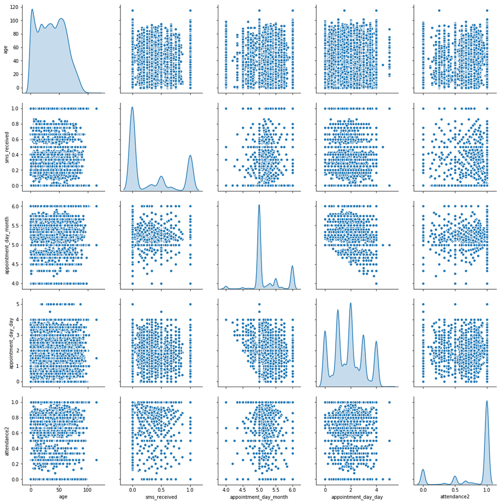

```python
# Let us use scatter plots to check the relationship between numerical variables.
# Variables of interest:
num_variables = ['age','sms_received','appointment_day_month','appointment_day_day','attendance2']

# Distribution of numerical variables and their relationship with each other:
sns.pairplot(data_patient[num_variables].mean(), diag_kind="kde", diag_kws=dict(shade=True), size=3)
plt.show();
```

> **Note:** Appointment year was omited here, because appointments were only taken in one year (2016).

**Observations**  
Taking a look at the numerical variable histograms and pair-wise plots, we may come up with some remarks.

*Distribution:*  
(1) Observing the age of patients, we notice that there is a steep increase in age close to 0 and a slower decrease towards the age of 100. No particular age is overrepresented, except for the age close to 0, suggesting that many patients were very young. (2) More than half of the patients did not receive notifications by SMS. (3) Apointments were mostly in May, then June and less frequently in average in April. (4) Appointments were set mostly in the middle of the week (Wednesday) and less frequently towards weekends.

*Relationship:*  
No strong relationships can be seen between any pair-wise variable combination in this dataset for the numerical variables. The graphs above (scater plots) show the distribution of points (observations) with no particular trend, such as a line that could suggest correlations.

### Categorical variables:

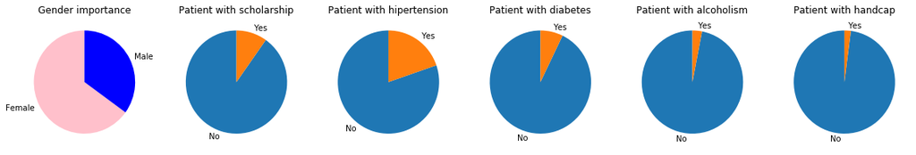

```python
# Categorical variables basically had two levels (except gender, they were all 0/1 variables)
# Plot all categorical variables comparing the total amount of these two levels per variable. For this, let us use Pie charts.
fig = plt.figure(figsize=(20,3))

# Subplot 1: Gender
ax1 = fig.add_subplot(161)
data['gender'].value_counts().plot(kind='pie', labels=['Female', 'Male'], colors=['pink','blue'], startangle=90)
plt.title('Gender importance')
plt.ylabel('')

# Subplot 2: Scholarship
ax2 = fig.add_subplot(162)
data['scholarship'].value_counts().plot(kind='pie', startangle=90)
plt.title('Patient with scholarship')
plt.ylabel('')

# Subplot 3: Hipertension
ax3 = fig.add_subplot(163)
data['hipertension'].value_counts().plot(kind='pie', startangle=90)
plt.title('Patient with hipertension')
plt.ylabel('')

# Subplot 4: Diabetes
ax4 = fig.add_subplot(164)
data['diabetes'].value_counts().plot(kind='pie', startangle=90)
plt.title('Patient with diabetes')
plt.ylabel('')

# Subplot 5: Alcoholism
ax5 = fig.add_subplot(165)
data['alcoholism'].value_counts().plot(kind='pie', startangle=90)
plt.title('Patient with alcoholism')
plt.ylabel('')

# Subplot 6: Handcap
ax6 = fig.add_subplot(166)
data['handcap'].value_counts().plot(kind='pie', startangle=90)
plt.title('Patient with handcap')
plt.ylabel('')

plt.show;
```

### Dependent variable: 'no-show' (and attendance)

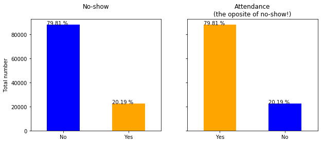

```python
# Let's see how no-show and attendance sum up in total numbers in this data
fig = plt.figure(figsize=(10,4))

# Subplot 1: No-show
ax1 = fig.add_subplot(121)
data['no_show'].value_counts().plot(kind='bar', color=['blue', 'orange'])
plt.title('No-show\n')
plt.ylabel('Total number')
plt.xticks(rotation=0)
# add percentages above bars
for p in ax1.patches:
    ax1.annotate(str(rate_to_percent(p.get_height()/data['no_show'].count())), xy=(p.get_x(), p.get_height()))

# Subplot 2: Attendance
ax2 = fig.add_subplot(122, sharey=ax1)
data['attendance'].value_counts().plot(kind='bar', color=['orange', 'blue'])
plt.title('Attendance\n(the oposite of no-show!)')
plt.xticks(rotation=0)
# add percentages above bars
for p in ax2.patches:
    ax2.annotate(str(rate_to_percent(p.get_height()/data['attendance'].count())), xy=(p.get_x(), p.get_height()))

plt.show;
```

> **Note:** The graph above on the right is redundant, because it shows the same information that is seen on the left (in an inverse way). The graph on the left, however, is still important to help us understand the variable 'No-show', which is the one we are interested in this analysis.

**Observation**  
The two bar plots above show that from all appointments in the data (over 100k), 20% of them were not succesful.  
That is, patients came to ca. 80% of the appointments.

## Main Data Analysis

### Question 1: Do no-shows occur more often in specific days or months?

```python
# To answer this question, let's think in terms of attendance instead of no-shows. (This will be the same for the following questions)
# This will in the end bring us to the same results.

# First, let us group the data by the six weekdays on which appointments could have taken place (MON to SAT)
weekday = data.groupby('appointment_day_day')['attendance2'].mean()
```

```python
# Then, let us print out the percentage of the total appointments assigned to each weekday.
print("Attendance percentage on MON: ", rate_to_percent(weekday[0]))
print("Attendance percentage on TUE: ", rate_to_percent(weekday[1]))
print("Attendance percentage on WED: ", rate_to_percent(weekday[2]))
print("Attendance percentage on THU: ", rate_to_percent(weekday[3]))
print("Attendance percentage on FRI: ", rate_to_percent(weekday[4]))
print("Attendance percentage on SAT: ", rate_to_percent(weekday[5]))
```

```
Attendance percentage on MON:  79.35 %
Attendance percentage on TUE:  79.91 %
Attendance percentage on WED:  80.31 %
Attendance percentage on THU:  80.65 %
Attendance percentage on FRI:  78.77 %
Attendance percentage on SAT:  76.92 %
```

```python
# Well, it seems that attendance is very similar among weekdays (ca. 80 %),
# but what about the attendance to appointments by months:
month = data.groupby('appointment_day_month')['attendance2'].mean()
```

```python
print("Attendance percentage in APR: ", rate_to_percent(month[4]))
print("Attendance percentage in MAY: ", rate_to_percent(month[5]))
print("Attendance percentage in JUN: ", rate_to_percent(month[6]))
```

```
Attendance percentage in APR:  80.43 %
Attendance percentage in MAY:  79.21 %
Attendance percentage in JUN:  81.54 %
```

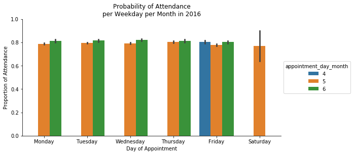

```python
# Again, month (like weekdays) do not seem to influence positively or negatively the number of no-shows to appointments.
# However, would that still hold true for specific weekdays within particular months?

# Now, instead of calculating percentages, let us visualize directly these groups with a bar plot.

# Create Seaborn figure:
fig = sns.factorplot(data=data, x='appointment_day_day', y='attendance2',
                     hue='appointment_day_month', kind='bar', size=4, aspect=2)
# Set figure configurations:
fig.set_axis_labels('Day of Appointment', 'Proportion of Attendance')
plt.title('Probability of Attendance\nper Weekday per Month in 2016')
fig.set(ylim=(0, 1))
fig.set(xticklabels=['Monday','Tuesday','Wednesday','Thursday','Friday','Saturday'])

plt.show();
```

```python
# According to the graph above, appointments in April (month 4) were only set on Fridays.
# Is this really true or attendance in April on the other weekdays was 0%?

# Besides, for June, attendance was None on Saturdays. Is this also true, or actually there was no appointment on that weekday on June?

# Let us look at the weekdays on the dataset for the months of April and June:
print("Weekdays and their count numbers for the month of April:")
print(data.query('appointment_day_month == 4').appointment_day_day.value_counts())
print("-"*40)
print("Weekdays and their count numbers for the month of June:")
print(data.query('appointment_day_month == 6').appointment_day_day.value_counts())
```

```
Weekdays and their count numbers for the month of April:
4    3235
Name: appointment_day_day, dtype: int64
----------------------------------------
Weekdays and their count numbers for the month of June:
2    8943
0    4691
1    4416
3    4310
4    4090
Name: appointment_day_day, dtype: int64
```

**Final observations**  
Looks like the first hypothesis is true: appointments in April were only set on Fridays. For June, no appointments were set on Saturdays. Therefore, this bring us back to the idea that neither weekdays nor months seem to be associated to more attendance (or no-shows).

### Question 2: Do no-shows occur more often among men or women?

```python
# To answer this question, let us look at the number of men and women patients and their attendance percentages

# How many appointments with men and women patients were set?
# Proportion of cumulative attendances by men and women:
print("Total number of attendances: ", sum(data['attendance2']))
print("Percentage of appointments with men: ", rate_to_percent(sum(data_m['attendance2'])/sum(data['attendance2'])))
print("Percentage of appointments with women: " , rate_to_percent(sum(data_f['attendance2'])/sum(data['attendance2'])))
```

```
Total number of attendances:  88207
Percentage of appointments with men:  35.1 %
Percentage of appointments with women:  64.9 %
```

```python
# And within each gender, how much is the attendance percentage?
print("Overall attendance percentage: ", rate_to_percent(data['attendance2'].mean()))
print("Men attendance percentage: ", rate_to_percent(data_m['attendance2'].mean()))
print("Women attendance percentage: ", rate_to_percent(data_f['attendance2'].mean()))
```

```
Overall attendance percentage:  79.81 %
Men attendance percentage:  80.03 %
Women attendance percentage:  79.69 %
```

We notice that more appointments were set with women than men (about two times more). However, there is no evidence by the numbers above that indicate that gender is associated with more attendances (or no-shows). Is this still true, when we look at unique patient records?

```python
print("Men attendance (unique patient): ", rate_to_percent(data_patient_m['attendance2'].mean().mean()))
print("Women attendance (unique patient): " ,rate_to_percent(data_patient_f['attendance2'].mean().mean()))
```

```
Men attendance (unique patient):  80.27 %
Women attendance (unique patient):  80.4 %
```

**Final observations**  
Even when grouping observations by mean values per patient ID, the difference between men and women is still very similar. Thus, whether the patient is a man or a woman, it does not seem that the amount of no-shows changes much.

### Question 3: Are no-shows related with a person's health status?

```python
# It may be that patients with some illness or condition have more difficulty to get to an appointment
# Constrastingly, they might be otherwise more keen on going to appointments, if they need to cure their illnesses.
# To answer this questions, let's compare the relationship of health conditions of patients with mean attendances

# Health conditions: 'hipertension', 'diabetes', 'alcoholism', 'handcap'
# Calculate the attendance means for each health condition
mean1 = data.groupby('hipertension')['attendance2'].mean()
mean2 = data.groupby('diabetes')['attendance2'].mean()
mean3 = data.groupby('alcoholism')['attendance2'].mean()
mean4 = data.groupby('handcap')['attendance2'].mean()
# Create the variables to plot:
x = ['hipertension', 'hipertension', 'diabetes', 'diabetes',
     'alcoholism', 'alcoholism', 'handcap', 'handcap']
y = mean1.append(mean2.append(mean3.append(mean4)))
status = y.index.values
```

```python
# Add variables to a new dataframe to use for plotting:
df = pd.DataFrame({'Health Condition': x, 'Presence Status': status, 'Attendance': y})
df
```

|  | Attendance | Health Condition | Presence Status |
| --- | --- | --- | --- |
| No | 0.790961 | hipertension | No |
| Yes | 0.826980 | hipertension | Yes |
| No | 0.796370 | diabetes | No |
| Yes | 0.819967 | diabetes | Yes |
| No | 0.798052 | alcoholism | No |
| Yes | 0.798512 | alcoholism | Yes |
| No | 0.797645 | handcap | No |
| Yes | 0.818385 | handcap | Yes |

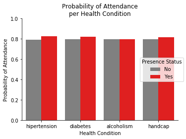

```python
# Now that we have the data prepared for plotting, let's create the seaborn figure
# Plot figure:
fig = sns.factorplot(data=df, x='Health Condition', y='Attendance',
                     hue='Presence Status', kind='bar', palette=['grey', 'red'])
# Set figure configurations:
fig.set(ylim=(0, 1))
plt.title('Probability of Attendance\nper Health Condition')
plt.ylabel('Probability of Attendance')

plt.tight_layout()
plt.show();
```

```python
# So, the answer is no. In average, health conditions do not seem to influence the rate of appointment attendance
# in this population, but wait, how often do patients have health conditions? It can be that our data is not so
# representative, and therefore we cannot detect differences in attendances due to health condition status.

# Let's look at the total amount of health conditions per appointment
mean1 = data.groupby('hipertension')['attendance'].count()
mean2 = data.groupby('diabetes')['attendance'].count()
mean3 = data.groupby('alcoholism')['attendance'].count()
mean4 = data.groupby('handcap')['attendance'].count()
# Create variables to plot:
x = ['hipertension', 'hipertension', 'diabetes', 'diabetes',
     'alcoholism', 'alcoholism', 'handcap', 'handcap']
y = mean1.append(mean2.append(mean3.append(mean4)))
status = y.index.values

df = pd.DataFrame({'Health Condition': x, 'Presence Status': status, 'Appointment': y})
df
```

|  | Appointment | Health Condition | Presence Status |
| --- | --- | --- | --- |
| No | 88725 | hipertension | No |
| Yes | 21801 | hipertension | Yes |
| No | 102583 | diabetes | No |
| Yes | 7943 | diabetes | Yes |
| No | 107166 | alcoholism | No |
| Yes | 3360 | alcoholism | Yes |
| No | 108285 | handcap | No |
| Yes | 2241 | handcap | Yes |

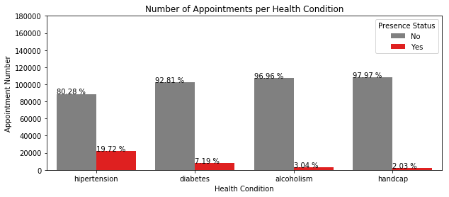

[figure not shown]

```python
# Now that we have the data prepared for plotting, let's create the seaborn figure
# Plot figure:
fig = plt.figure(figsize=(10,4))
ax1 = fig.add_subplot(111)
sns.factorplot(data=df, x='Health Condition', y='Appointment',
               hue='Presence Status', kind='bar', palette=['grey', 'red'], ax=ax1)
# Set figure configurations:
ax1.set_title('Number of Appointments per Health Condition')
ax1.set_ylabel('Appointment Number')
ax1.set(ylim=(0, 180000))

# Add percentage importance per bar:
for p in ax1.patches:
    ax1.annotate(str(rate_to_percent(p.get_height()/data['attendance'].count())), xy=(p.get_x(), p.get_height()));
```

> **Note:** The code above produces one empty plot. Unfortunately I could not solve this problem, even after consulting the internet or the Slack community.

### Question 4: Is social support influencing the rate of appointment no-shows?

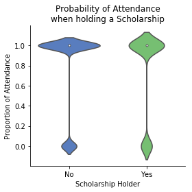

```python
# Patients holding a scholarship (financial support) would be expected to have more chances to go to the appointments,
# because they would have money to afford trasportation

# So, let us plot a figure that shows the importance of scholarship to attendance rate
# Plot seaborn figure:
fig = sns.factorplot(data=data, x='scholarship', y='attendance2',
                     kind='violin', palette='muted')
# Set figure configurations:
fig.set_axis_labels('Scholarship Holder', 'Proportion of Attendance')
plt.title('Probability of Attendance\nwhen holding a Scholarship')

plt.tight_layout()
plt.show();
```

```python
# Unexpectedly, patients with scholarships (smaller green violins above) showed-up less (lower attendance) than patients without scholarships
# Let us calculate this difference in terms of total numbers and proportion

data.groupby('scholarship')['attendance2'].value_counts()
```

```
scholarship  attendance2
No           1              79924
             0              19741
Yes          1               8283
             0               2578
Name: attendance2, dtype: int64
```

```python
print("Attendance rate for patients without scholarships: ", round(79924/(79924+19741),2))
print("Attendance rate for patients with scholarships: ", round(8283/(8283+2578),2))
```

```
Attendance rate for patients without scholarships:  0.8
Attendance rate for patients with scholarships:  0.76
```

```python
total_attendances = 79924 + 8283
print("Proportion of patients attending appointments...\nwith a scholarship: ", round(8283/total_attendances,2))
print("without a scholarship: ", round(79924/total_attendances,2))
```

```
Proportion of patients attending appointments...
with a scholarship:  0.09
without a scholarship:  0.91
```

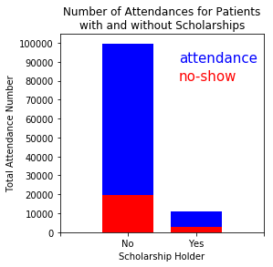

```python
# Wow! Looking in total numbers we observe that about 90% of attendances was within patients WITHOUT scholarships
# Scholarship holders are really an exception. Let us plot this difference.

# Plot figure and set configurations:
fig = plt.figure(figsize=(4,4))
ax1 = fig.add_subplot(111)

N = 2
Nos = (19741, 2578)
Yess = (79924, 8283)
ind = np.arange(N)   # the x locations for the groups
width = 0.75         # the width of the bars: can also be len(x) sequence

# Stacked bars
p1 = ax1.bar(ind, Nos, width, color='red')
p2 = ax1.bar(ind, Yess, width, color='blue', bottom=Nos)

# Plot configurations
ax1.set_ylabel('Total Attendance Number')
ax1.set_xlabel('Scholarship Holder')
ax1.set_title('Number of Attendances for Patients\nwith and without Scholarships')
ax1.set_xticks(ind)
ax1.set_yticks(np.arange(0, 110000, 10000))
ax1.set_xticks(np.arange(-1, 3))
ax1.set_xticklabels(('', 'No', 'Yes'))

ax1.text(0.75, 80000, 'no-show', color='red', fontsize=15)
ax1.text(0.75, 90000, 'attendance', color='blue', fontsize=15)

plt.show();
```

### Question 5: Is distance from appointment locations related to no-shows?

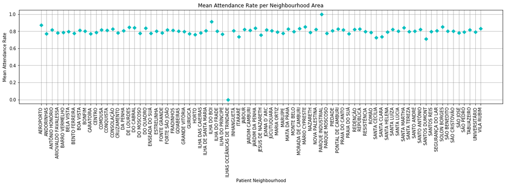

```python
# We don't have information about the exact distance from each patient's neighbourhood to their respective appointment location
# However, it is reasonable to think that some neighbourhoods are farther than others to the appointment locations. Thus,
# we could expect that the variable 'neighbourhood' could be associated with more or less attendance, since distance to
# the appointment might be a barrier/impediment for patients.

# To answer this questions, let's find out how neighbourhoods relate to the number of attendances
# Group observations by neighbourhoods to look at their mean attendance rates
means = data.groupby('neighbourhood')['attendance2'].mean()
# Plot figure
plt.figure(figsize=(20,4))
plt.plot(means.index.values, means, 'cD')
plt.title('Mean Attendance Rate per Neighbourhood Area')
plt.ylabel('Mean Attendance Rate')
plt.xlabel('Patient Neighbourhood')
plt.xticks(rotation=90)
plt.grid(color='grey', linestyle='-', linewidth=0.5)

plt.show;
```

```python
# Let#s find the neighbourhoods that diverged from the approximate attendance mean in the dataset
# Threshold to select values:
threshold = means.mean()
# Which neighbourhoods had relatively low attendances?
print("Neighbourhoods with low attendance rates: ", means.loc[means < threshold-0.1])

# Which neighbourhoods had relatively high attendances?
print("\nNeighbourhoods with large attendance rates: ", means.loc[means > threshold+0.1])
```

```
Neighbourhoods with low attendance rates:  neighbourhood
ILHAS OCEÂNICAS DE TRINDADE    0.0
Name: attendance2, dtype: float64

Neighbourhoods with large attendance rates:  neighbourhood
ILHA DO BOI          0.914286
PARQUE INDUSTRIAL    1.000000
Name: attendance2, dtype: float64
```

**Observation**  
The graph above shows all of the reported neighbourhoods of patients and their relationship with mean attendance rates. We may notice that the majority of neighbourhoods are associated with ca. 80% attendance. "ILHAS OCEÂNICAS DE TRINDADE", however, had almost no attendance, and patients from this region had a very high no-show. On the contrary, patients from the "ILHA DO BOI" and "PARQUE INDUSTRIAL" had average attendances quite larger than the mean average of the data. This suggests that for patients of some neighbourhoods, it might be harder or easier to get to their appointments.

### Question 6: Does the SMS message number influence the rate of no-shows?

```python
# To answer this questions, we first need to get the number of SMS messages per patient and combine it with the mean attendance rate per patient
# SMS received per patient (independent variable):
x = data_patient['sms_received'].sum()
# Mean attendance rate per patient (dependent variable):
y = data_patient['attendance2'].mean()

# Combine these two variables in one new dataframe (df2), to allow us for easily plotting a graph:
df1 = pd.DataFrame({'sms' : x, 'attendance': y})
df2 = df1.groupby('sms').mean()
df2['sms'] = df2.index.values
df2
```

| sms | attendance | sms |
| --- | --- | --- |
| 0 | 0.842664 | 0 |
| 1 | 0.755059 | 1 |
| 2 | 0.741186 | 2 |
| 3 | 0.743251 | 3 |
| 4 | 0.765122 | 4 |
| 5 | 0.806062 | 5 |
| 6 | 0.782588 | 6 |
| 7 | 0.855891 | 7 |
| 8 | 0.844277 | 8 |
| 9 | 0.687500 | 9 |
| 13 | 0.947368 | 13 |
| 16 | 0.800000 | 16 |

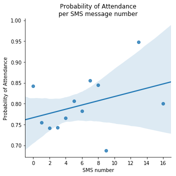

```python
# Now that we have the variables prepared, let us look at their relatioship.
# Since we have two numerical variables, lets make a regression plot using a scatter plot in Seaborn.

# Plot figure:
fig = sns.lmplot(data=df2, x="sms", y="attendance", ci=95, size=5)
# Set figure configurations:
plt.title('Probability of Attendance\nper SMS message number')
plt.xlabel('SMS number')
plt.ylabel('Probability of Attendance')

plt.tight_layout()
plt.show();
```

## Conclusions

### Limitations of this analysis:

It is still important to bare in mind that these analysis are descriptive and no statistical tests have been carried out. In other words, we cannot truly explain the behavior of patients regarding their attendance to medical consultations by only looking at these few variables represented in some graphical visualizations. Statistical tests should also be performed, perhaps including additional variables that were not covered here in order for us to make stronger interpretations about this dataset.